# EDA of NYC MTA Turnstile

## by Yoga Pratama

## Data Information

Collected from http://web.mta.info/developers/turnstile.html

Field description:  
C/A = Control Area (A002)  
UNIT = Remote Unit for a station (R051)  
SCP = Subunit Channel Position represents an specific address for a device (02-00-00)  
STATION = Represents the station name the device is located at  
LINENAME = Represents all train lines that can be boarded at this station Normally lines are represented by one character.  
DIVISION = Represents the Line originally the station belonged to BMT, IRT, or IND  
DATE = Represents the date (MM-DD-YY)  
TIME = Represents the time (hh:mm:ss) for a scheduled audit event  
DESC = Represent the "REGULAR" scheduled audit event (Normally occurs every 4 hours)

```
       1. Audits may occur more that 4 hours due to planning, or troubleshooting activities.
       2. Additionally, there may be a "RECOVR AUD" entry: This refers to a missed audit that was recovered.
```

ENTRIES = The comulative entry register value for a device  
EXIST = The cumulative exit register value for a device

# Data Preprocessing

```python
#Import module
import pandas as pd
import numpy as np
import matplotlib.pyplot as plt
import seaborn as sns
import folium
from collections import defaultdict
pd.options.display.float_format = '{:.2f}'.format
```

```python
#read from web (prioritise on June)
june = [180602, 180609, 180616, 180623, 180630]
url = 'http://web.mta.info/developers/data/nyct/turnstile/turnstile_{}.txt'
df_list = []
for week in june:
    df_list.append(pd.read_csv(url.format(week)))
df_mta = pd.concat(df_list)
```

```python
print (df_mta.shape)
```

```
(983733, 11)
```

```python
#Glimpse of the dataset, this dataset already subsetted to June 2018
df_mta.head(10)
```

|  | C/A | UNIT | SCP | STATION | LINENAME | DIVISION | DATE | TIME | DESC | ENTRIES | EXITS |
| --- | --- | --- | --- | --- | --- | --- | --- | --- | --- | --- | --- |
| 0 | A002 | R051 | 02-00-00 | 59 ST | NQR456W | BMT | 05/26/2018 | 00:00:00 | REGULAR | 6633898 | 2248498 |
| 1 | A002 | R051 | 02-00-00 | 59 ST | NQR456W | BMT | 05/26/2018 | 04:00:00 | REGULAR | 6633916 | 2248500 |
| 2 | A002 | R051 | 02-00-00 | 59 ST | NQR456W | BMT | 05/26/2018 | 08:00:00 | REGULAR | 6633928 | 2248517 |
| 3 | A002 | R051 | 02-00-00 | 59 ST | NQR456W | BMT | 05/26/2018 | 12:00:00 | REGULAR | 6634015 | 2248577 |
| 4 | A002 | R051 | 02-00-00 | 59 ST | NQR456W | BMT | 05/26/2018 | 16:00:00 | REGULAR | 6634173 | 2248610 |
| 5 | A002 | R051 | 02-00-00 | 59 ST | NQR456W | BMT | 05/26/2018 | 20:00:00 | REGULAR | 6634367 | 2248645 |
| 6 | A002 | R051 | 02-00-00 | 59 ST | NQR456W | BMT | 05/27/2018 | 00:00:00 | REGULAR | 6634496 | 2248662 |
| 7 | A002 | R051 | 02-00-00 | 59 ST | NQR456W | BMT | 05/27/2018 | 04:00:00 | REGULAR | 6634503 | 2248664 |
| 8 | A002 | R051 | 02-00-00 | 59 ST | NQR456W | BMT | 05/27/2018 | 08:00:00 | REGULAR | 6634514 | 2248675 |
| 9 | A002 | R051 | 02-00-00 | 59 ST | NQR456W | BMT | 05/27/2018 | 12:00:00 | REGULAR | 6634542 | 2248713 |

```python
#Count the number of entries and exits for each day
#keep column needed for exploration
df_turnstile.head(10)
```

|  | C/A | Unit | SCP | Station | Linename | Date | Entries | Exits |
| --- | --- | --- | --- | --- | --- | --- | --- | --- |
| 0 | A002 | R051 | 02-00-00 | 59 ST | 456NQRW | 05/26/2018 | 469 | 147 |
| 1 | A002 | R051 | 02-00-00 | 59 ST | 456NQRW | 05/27/2018 | 360 | 114 |
| 2 | A002 | R051 | 02-00-00 | 59 ST | 456NQRW | 05/28/2018 | 450 | 143 |
| 3 | A002 | R051 | 02-00-00 | 59 ST | 456NQRW | 05/29/2018 | 1154 | 526 |
| 4 | A002 | R051 | 02-00-00 | 59 ST | 456NQRW | 05/30/2018 | 1244 | 553 |
| 5 | A002 | R051 | 02-00-00 | 59 ST | 456NQRW | 05/31/2018 | 1297 | 521 |
| 6 | A002 | R051 | 02-00-00 | 59 ST | 456NQRW | 06/01/2018 | 1292 | 516 |
| 7 | A002 | R051 | 02-00-01 | 59 ST | 456NQRW | 05/26/2018 | 411 | 81 |
| 8 | A002 | R051 | 02-00-01 | 59 ST | 456NQRW | 05/27/2018 | 308 | 68 |
| 9 | A002 | R051 | 02-00-01 | 59 ST | 456NQRW | 05/28/2018 | 406 | 94 |

```python
# detecting outliers
df_turnstile.describe()
```

|  | Entries | Exits |
| --- | --- | --- |
| count | 164362.00 | 164362.00 |
| mean | 83124.58 | 66845.52 |
| std | 10973003.00 | 9203784.69 |
| min | 0.00 | 0.00 |
| 25% | 237.00 | 130.00 |
| 50% | 732.00 | 445.00 |
| 75% | 1431.00 | 1007.00 |
| max | 2113959893.00 | 1838305870.00 |

```python
#Using IQR method to clean the data frame
#Check the cleaned dataframe
df_turnstile_cln = df_turnstile[~((df_turnstile < (Q1 - 1.5 * IQR)) |(df_turnstile > (Q3 + 1.5 * IQR))).any(axis=1)]
print (df_turnstile_cln.describe())
print (df_turnstile_cln.shape)
```

```
        Entries     Exits
count 151460.00 151460.00
mean     843.14    562.20
std      760.62    559.63
min        0.00      0.00
25%      200.00    107.00
50%      665.00    389.00
75%     1302.00    855.00
max     3222.00   2322.00
(151460, 8)
```

```python
#Change the format of Date and Time to datetime
df_turnstile_cln['Date'] = pd.to_datetime(df_turnstile_cln.loc[:, 'Date'], format = '%m/%d/%Y')
print (df_turnstile_cln.dtypes)
```

```
C/A                 object
Unit                object
SCP                 object
Station             object
Linename            object
Date        datetime64[ns]
Entries              int64
Exits                int64
dtype: object
```

[output not shown]

## Create Location data frame

```python
#Thanks to https://github.com/chriswhong/nycturnstiles Chriswhong
NYC_transit = 'geocoded.csv'

subway_location = pd.read_csv(NYC_transit, header = None, names = ['Unit', 'C/A', 'Station', 'Linename', 'Division', 'Lat', 'Lng'])
subway_location.head()
```

|  | Unit | C/A | Station | Linename | Division | Lat | Lng |
| --- | --- | --- | --- | --- | --- | --- | --- |
| 0 | R470 | X002 | ELTINGVILLE PK | Z | SRT | 40.54 | -74.16 |
| 1 | R544 | PTH02 | HARRISON | 1 | PTH | 40.74 | -74.16 |
| 2 | R165 | S102 | TOMPKINSVILLE | 1 | SRT | 40.64 | -74.07 |
| 3 | R070 | S101 | ST. GEORGE | 1 | SRT | 40.64 | -74.07 |
| 4 | R070 | S101A | ST. GEORGE | 1 | SRT | 40.64 | -74.07 |

```python
#merge turnstile df with location
df = pd.merge(df_turnstile_cln, df_stat_loc, on='Unit', how='left')
df
```

|  | C/A | Unit | SCP | Station | Linename | Date | Entries | Exits | Lat | Lng |
| --- | --- | --- | --- | --- | --- | --- | --- | --- | --- | --- |
| 0 | A002 | R051 | 02-00-00 | 59 ST | 456NQRW | 2018-05-26 | 469 | 147 | 40.76 | -73.97 |
| 1 | A002 | R051 | 02-00-00 | 59 ST | 456NQRW | 2018-05-27 | 360 | 114 | 40.76 | -73.97 |
| 2 | A002 | R051 | 02-00-00 | 59 ST | 456NQRW | 2018-05-28 | 450 | 143 | 40.76 | -73.97 |
| 3 | A002 | R051 | 02-00-00 | 59 ST | 456NQRW | 2018-05-29 | 1154 | 526 | 40.76 | -73.97 |
| 4 | A002 | R051 | 02-00-00 | 59 ST | 456NQRW | 2018-05-30 | 1244 | 553 | 40.76 | -73.97 |
| ... | ... | ... | ... | ... | ... | ... | ... | ... | ... | ... |
| 155641 | TRAM2 | R469 | 00-03-01 | RIT-ROOSEVELT | R | 2018-06-25 | 1458 | 32 | 40.76 | -73.95 |
| 155642 | TRAM2 | R469 | 00-03-01 | RIT-ROOSEVELT | R | 2018-06-26 | 1384 | 18 | 40.76 | -73.95 |
| 155643 | TRAM2 | R469 | 00-03-01 | RIT-ROOSEVELT | R | 2018-06-27 | 1590 | 38 | 40.76 | -73.95 |
| 155644 | TRAM2 | R469 | 00-03-01 | RIT-ROOSEVELT | R | 2018-06-28 | 1270 | 21 | 40.76 | -73.95 |
| 155645 | TRAM2 | R469 | 00-03-01 | RIT-ROOSEVELT | R | 2018-06-29 | 1608 | 40 | 40.76 | -73.95 |

155646 rows × 10 columns

# Data Exploration

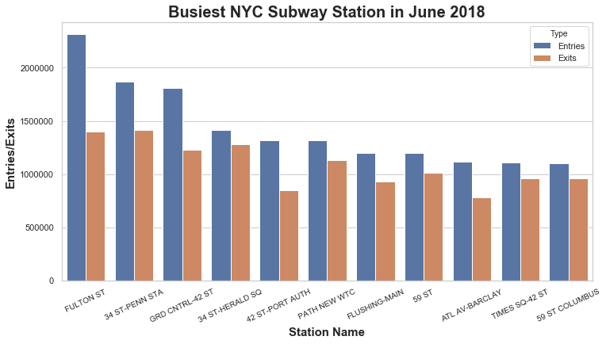

```python
#Plot busiest station in NYC
plt.figure (figsize=(12,6))
sns.set(style = "whitegrid")
sns.barplot(df2['Station'], df2['Count'], hue = df2['Type'])
plt.title("Busiest NYC Subway Station in June 2018", fontsize=20, weight='bold')
plt.xlabel("Station Name", fontsize=15, weight='bold')
plt.ylabel("Entries/Exits", fontsize=15, weight='bold')
plt.xticks(rotation=25, fontsize=10)
```

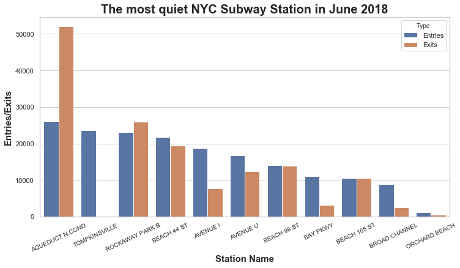

```python
#Plot most quiet place in NYC
plt.figure (figsize=(12,6))
sns.set(style = "whitegrid")
sns.barplot(df4['Station'], df4['Count'], hue = df4['Type'])
plt.title("The most quiet NYC Subway Station in June 2018", fontsize=20, weight='bold')
plt.xlabel("Station Name", fontsize=15, weight='bold')
plt.ylabel("Entries/Exits", fontsize=15, weight='bold')
plt.xticks(rotation=25, fontsize=10)
```

```python
#Maps markers for busy station
base_map1 = generateBaseMap()
for row in df_busy_loc.iterrows():
    row_values = row[1]
    location = [row_values['Lat'], row_values['Lng']]
    popup = popup ='<strong>' + row_values['Station'] + '</strong>'
    marker = folium.Marker(location = location, popup = popup)
    marker.add_to(base_map1)
display(base_map1)
```

[interactive chart not shown]

```python
#Maps markers for quiet Station
base_map2 = generateBaseMap()
for row in df_quiet_loc.iterrows():
    row_values = row[1]
    location = [row_values['Lat'], row_values['Lng']]
    popup = popup ='<strong>' + row_values['Station'] + '</strong>'
    marker = folium.Marker(location = location, popup = popup)
    marker.add_to(base_map2)
display(base_map2)
```

[interactive chart not shown]

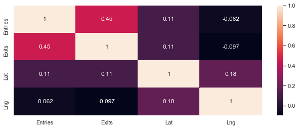

```python
#Correlation between numerical value
plt.figure(figsize=(11,4))
sns.heatmap(df.corr(),annot=True)
plt.show()
```

## Time Series

```python
#Subset for busiest station
df_timeseries = df5.groupby(['Linename', 'Station', 'Date'], as_index=False).sum()
busy = df1['Station']
busy = busy[:5]
df_timeseries = df_timeseries[df_timeseries['Station'].isin(busy)]
df_timeseries
```

|  | Linename | Station | Date | Count |
| --- | --- | --- | --- | --- |
| 1680 | 123 | 34 ST-PENN STA | 2018-05-26 | 22623 |
| 1681 | 123 | 34 ST-PENN STA | 2018-05-27 | 17490 |
| 1682 | 123 | 34 ST-PENN STA | 2018-05-28 | 19705 |
| 1683 | 123 | 34 ST-PENN STA | 2018-05-29 | 30835 |
| 1684 | 123 | 34 ST-PENN STA | 2018-05-30 | 32438 |
| ... | ... | ... | ... | ... |
| 12563 | G | FULTON ST | 2018-06-25 | 8156 |
| 12564 | G | FULTON ST | 2018-06-26 | 8872 |
| 12565 | G | FULTON ST | 2018-06-27 | 7521 |
| 12566 | G | FULTON ST | 2018-06-28 | 6878 |
| 12567 | G | FULTON ST | 2018-06-29 | 7592 |

315 rows × 4 columns

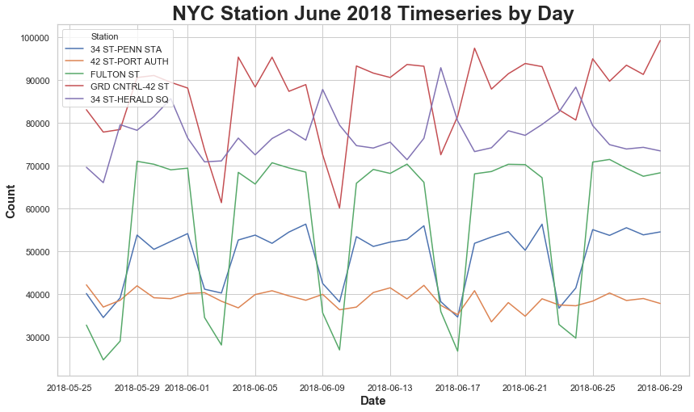

```python
plt.figure(figsize = (14, 8))
ax = sns.lineplot(data=df_timeseries, x="Date", y="Count", hue="Station", ci=None)
ax.set_title('NYC Station June 2018 Timeseries by Day', fontsize=25, weight='bold')
ax.set_xlabel('Date', fontsize=15, weight='bold')
ax.set_ylabel('Count', fontsize=15, weight='bold')
```

## From the graph:

1. Subway station is decreasing over the weekend, and will be busy again on the weekday
2. Anomaly on 34 ST-Herald SQ station (this station is in business area)
3. The peak of every cycle is the same for each week (regular customers)

## Exploring using Heatmap and TimeSlider

```python
base_map
```

[interactive chart not shown]

```python
#Heatmap with day time entry
from folium.plugins import HeatMapWithTime
base_map = generateBaseMap(default_zoom_start=11)
HeatMapWithTime(df_day_list, radius=20, min_opacity=0.5, max_opacity=0.8, use_local_extrema=True).add_to(base_map)
base_map
```

[interactive chart not shown]

```python
base_map = generateBaseMap(default_zoom_start=11)
HeatMapWithTime(df_day_list_exits, radius=20, min_opacity=0.5, max_opacity=0.8, use_local_extrema=True).add_to(base_map)
base_map
```

[interactive chart not shown]

## From the Heatmap:

1. Business area is always crowded compare to the other area
2. North side of the city is bussier compare to south area

# Relationship for predicting the crime

1. Does the crowd size of an area (represented by stations) affect the crime rate?
2. Whether lot of crime happened at the stations/near the stations?
3. What time does the crime usually happened (can connect to crowd size in the station)